# Practical Machine Learning: Project Assessment

git-comp

20 May 2021

## Assignment

The coursera assignment states: > Using devices such as Jawbone Up, Nike FuelBand, and Fitbit it is now possible to collect a large amount of data about personal activity relatively inexpensively. These type of devices are part of the quantified self movement ??? a group of enthusiasts who take measurements about themselves regularly to improve their health, to find patterns in their behavior, or because they are tech geeks. One thing that people regularly do is quantify how much of a particular activity they do, but they rarely quantify how well they do it. In this project, your goal will be to use data from accelerometers on the belt, forearm, arm, and dumbell of 6 participants. They were asked to perform barbell lifts correctly and incorrectly in 5 different ways. More information is available from the website (here)[http://groupware.les.inf.puc-rio.br/har] (see the section on the Weight Lifting Exercise Dataset).

## Introduction

This document summarizes my approach to this assignment.

## Loading the data

```r
library("data.table")
library(ggplot2)
library(caret)
set.seed(1234)
## Training Set
trainingUrl <- "https://d396qusza40orc.cloudfront.net/predmachlearn/pml-training.csv"
download.file(trainingUrl, destfile = paste0(getwd(), '/pml-training.csv'), method = "curl")
trainingData <- read.csv("./pml-training.csv", na.strings=c("NA", ""))
dim(trainingData)
```

```
## [1] 19622   160
```

```r
str(trainingData)
```

```
## 'data.frame':    19622 obs. of  160 variables:
##  $ X                       : int  1 2 3 4 5 6 7 8 9 10 ...
##  $ user_name               : chr  "carlitos" "carlitos" "carlitos" "carlitos" ...
##  $ raw_timestamp_part_1    : int  1323084231 1323084231 1323084231 1323084232 1323084232 1323084232 1323084232 1323084232 1323084232 1323084232 ...
##  $ raw_timestamp_part_2    : int  788290 808298 820366 120339 196328 304277 368296 440390 484323 484434 ...
##  $ cvtd_timestamp          : chr  "05/12/2011 11:23" "05/12/2011 11:23" "05/12/2011 11:23" "05/12/2011 11:23" ...
##  $ new_window              : chr  "no" "no" "no" "no" ...
##  $ num_window              : int  11 11 11 12 12 12 12 12 12 12 ...
##  $ roll_belt               : num  1.41 1.41 1.42 1.48 1.48 1.45 1.42 1.42 1.43 1.45 ...
##  $ pitch_belt              : num  8.07 8.07 8.07 8.05 8.07 8.06 8.09 8.13 8.16 8.17 ...
##  $ yaw_belt                : num  -94.4 -94.4 -94.4 -94.4 -94.4 -94.4 -94.4 -94.4 -94.4 -94.4 ...
##  $ total_accel_belt        : int  3 3 3 3 3 3 3 3 3 3 ...
##  $ kurtosis_roll_belt      : chr  NA NA NA NA ...
##  $ kurtosis_picth_belt     : chr  NA NA NA NA ...
##  $ kurtosis_yaw_belt       : chr  NA NA NA NA ...
```

[output cut: 86 more lines]

```r
## Testing Set
testingUrl <- "https://d396qusza40orc.cloudfront.net/predmachlearn/pml-testing.csv"
download.file(testingUrl, destfile = paste0(getwd(), '/pml-testing.csv'), method = "curl")
testData <- read.csv("./pml-testing.csv", na.strings=c("NA", ""))
dim(testData)
```

```
## [1]  20 160
```

```r
str(trainingData)
```

```
## 'data.frame':    19622 obs. of  160 variables:
##  $ X                       : int  1 2 3 4 5 6 7 8 9 10 ...
##  $ user_name               : chr  "carlitos" "carlitos" "carlitos" "carlitos" ...
##  $ raw_timestamp_part_1    : int  1323084231 1323084231 1323084231 1323084232 1323084232 1323084232 1323084232 1323084232 1323084232 1323084232 ...
##  $ raw_timestamp_part_2    : int  788290 808298 820366 120339 196328 304277 368296 440390 484323 484434 ...
##  $ cvtd_timestamp          : chr  "05/12/2011 11:23" "05/12/2011 11:23" "05/12/2011 11:23" "05/12/2011 11:23" ...
##  $ new_window              : chr  "no" "no" "no" "no" ...
##  $ num_window              : int  11 11 11 12 12 12 12 12 12 12 ...
##  $ roll_belt               : num  1.41 1.41 1.42 1.48 1.48 1.45 1.42 1.42 1.43 1.45 ...
##  $ pitch_belt              : num  8.07 8.07 8.07 8.05 8.07 8.06 8.09 8.13 8.16 8.17 ...
##  $ yaw_belt                : num  -94.4 -94.4 -94.4 -94.4 -94.4 -94.4 -94.4 -94.4 -94.4 -94.4 ...
##  $ total_accel_belt        : int  3 3 3 3 3 3 3 3 3 3 ...
##  $ kurtosis_roll_belt      : chr  NA NA NA NA ...
##  $ kurtosis_picth_belt     : chr  NA NA NA NA ...
##  $ kurtosis_yaw_belt       : chr  NA NA NA NA ...
```

[output cut: 86 more lines]

From the str() command, we see that many of the 160 columns contain NA or blank values. So I decide to remove columns where more than 75% of the values are NA or blank, as 75% of missing values are too many to impute some artificial values.

```r
prunedTrainingData <- trainingData[,-which(colSums(is.na(trainingData) | trainingData == "") > 0.75 * dim(trainingData)[1])]
dim(prunedTrainingData)
```

```
## [1] 19622    60
```

```r
prunedTestData <- testData[,-which(colSums(is.na(testData) | testData == "") > 0.75 * dim(testData)[1])]
dim(prunedTestData)
```

```
## [1] 20 60
```

Additionally, columns 1 to 7 only contain user specific data, which should not be relevant for our model. It will be removed, as well:

```r
prunedTrainingData <- prunedTrainingData[,-c(1:7)]
dim(prunedTrainingData)
```

```
## [1] 19622    53
```

```r
prunedTestData <- prunedTestData[,-c(1:7)]
dim(prunedTestData)
```

```
## [1] 20 53
```

For cross validation, we will split the prunedTrainingData into two sets:

```r
inTrain <- createDataPartition(prunedTrainingData$classe, p=0.70, list=FALSE)
splitTrainingData <- prunedTrainingData[inTrain, ]
splitCrossvalidationData <- prunedTrainingData[-inTrain, ]
```

## Random Forest

```r
tr <- trainControl(method="cv", number=5)
randomForestMod <- train(classe~., data=splitTrainingData, method="rf", trControl=tr, verbose=FALSE)
randomForestMod
```

```
## Random Forest
##
## 13737 samples
##    52 predictor
##     5 classes: 'A', 'B', 'C', 'D', 'E'
##
## No pre-processing
## Resampling: Cross-Validated (5 fold)
## Summary of sample sizes: 10989, 10991, 10989, 10991, 10988
## Resampling results across tuning parameters:
##
##   mtry  Accuracy   Kappa
##    2    0.9909732  0.9885808
##   27    0.9910464  0.9886728
##   52    0.9842034  0.9800155
##
## Accuracy was used to select the optimal model using the largest value.
## The final value used for the model was mtry = 27.
```

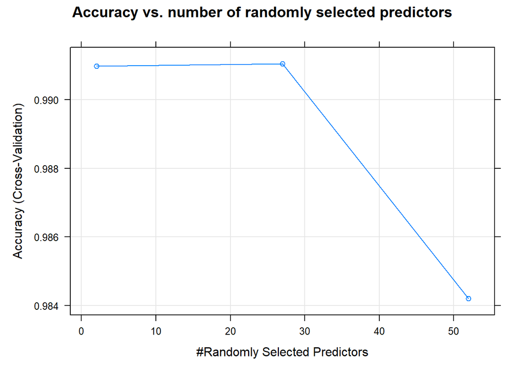

```r
## Plot Accuracy vs. number of randomly selected predictors
plot(randomForestMod, main="Accuracy vs. number of randomly selected predictors")
```

```r
## Use cv set to check for accuracy
predictCrossValidate <- predict(randomForestMod, newdata=splitCrossvalidationData)
confusionMatrixRandomForest <- confusionMatrix(factor(splitCrossvalidationData$classe), predictCrossValidate)
confusionMatrixRandomForest$table
```

```
##           Reference
## Prediction    A    B    C    D    E
##          A 1673    0    1    0    0
##          B    5 1129    5    0    0
##          C    0   14 1010    2    0
##          D    0    0    8  955    1
##          E    0    0    0    0 1082
```

```r
confusionMatrixRandomForest$overall["Accuracy"]
```

```
##  Accuracy
## 0.9938828
```

```r
## Show most important variables of model
varImp(randomForestMod)
```

```
## rf variable importance
##
##   only 20 most important variables shown (out of 52)
##
##                      Overall
## roll_belt             100.00
## pitch_forearm          61.24
## yaw_belt               54.65
## roll_forearm           45.53
## magnet_dumbbell_z      45.13
## magnet_dumbbell_y      44.05
## pitch_belt             43.89
## accel_dumbbell_y       24.56
## roll_dumbbell          17.74
## accel_forearm_x        17.14
## magnet_dumbbell_x      16.35
## magnet_belt_z          15.75
## magnet_forearm_z       14.99
## accel_dumbbell_z       14.38
## total_accel_dumbbell   13.38
## accel_belt_z           13.19
## magnet_belt_y          12.89
## gyros_belt_z           12.76
## yaw_arm                10.96
## magnet_belt_x          10.39
```

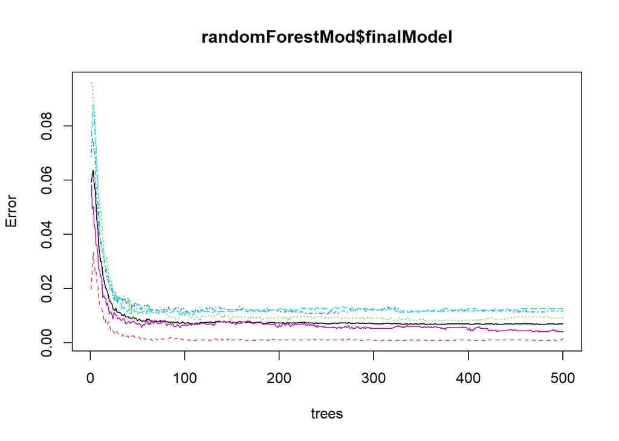

```r
plot(randomForestMod$finalModel)
```

## Conclusion

```r
predict(randomForestMod, newdata=prunedTestData)
```

```
##  [1] B A B A A E D B A A B C B A E E A B B B
## Levels: A B C D E
```